# Problem Set 1

Author

Xiuyu Cao

Published

March 24, 2024

## 0.1 Lab Setup

Set your working directory and load libraries.

```r
library(tidyverse)
library(car)
```

# 1 Question 1

```r
# The test socres of 3 groups of students from EAS 538
data1 <- read.csv('../data/problemset1/data_q1.csv')
head(data1, 3)
```

```
   group   scores
1 group1 91.23661
2 group1 92.45948
3 group1 81.99049
```

## 1.1 a

**Answer**:

- $H_0:$ There is no difference in the test scores of the 3 student groups.
- $H_A:$ At least one of the 3 student groups has different mean scores comparing to the others.

## 1.2 b

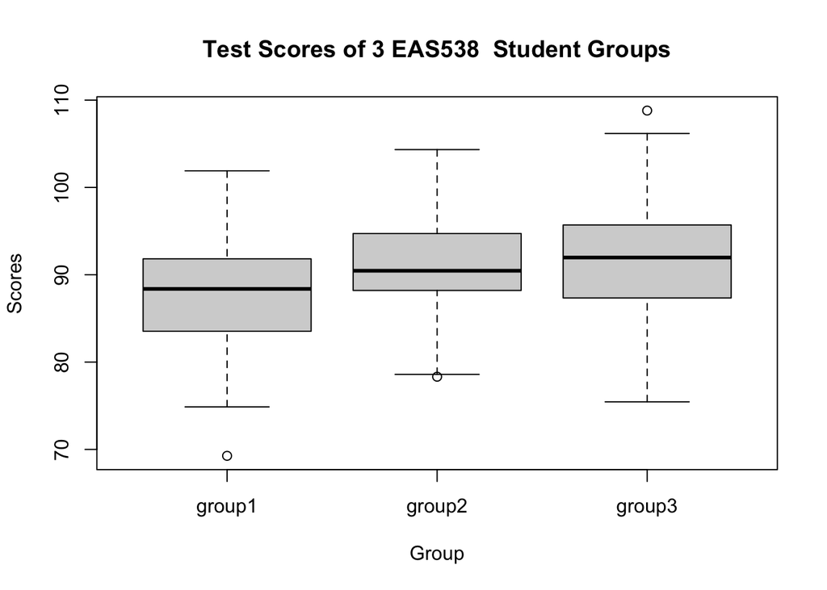

```r
boxplot(scores~group, data=data1,
        xlab='Group', ylab='Scores', main='Test Scores of 3 EAS538  Student Groups')
```

From the plot, the mean score of group 1 seem lower than that of the other two groups.

## 1.3 c

**Answer**: 3 groups, continuous y and categorical x –> Use ANOVA.

```r
## Check ANOVA assumptions

# Equal Variance
leveneTest(scores~group, data1, center=mean)
```

```
Levene's Test for Homogeneity of Variance (center = mean)
       Df F value Pr(>F)
group   2  1.3344 0.2649
      297
```

```r
# Normality
group1 <- filter(data1, group=='group1')
group2 <- filter(data1, group=='group2')
group3 <- filter(data1, group=='group3')

dim(group1)
```

```
[1] 100   2
```

```r
dim(group2)
```

```
[1] 100   2
```

```r
dim(group3)
```

```
[1] 100   2
```

```r
shapiro.test(group1$scores)
```

```
    Shapiro-Wilk normality test

data:  group1$scores
W = 0.99294, p-value = 0.8845
```

```r
shapiro.test(group2$scores)
```

```
    Shapiro-Wilk normality test

data:  group2$scores
W = 0.99045, p-value = 0.7011
```

```r
shapiro.test(group3$scores)
```

```
    Shapiro-Wilk normality test

data:  group3$scores
W = 0.99378, p-value = 0.9302
```

**Conclusion**

- Continuous response data –> Met
- Samples must be independent –> Assume so
- Each population must have the same variance –> From the output of the `leveneTest()`, the p value is $0.26>\alpha=0.05$. We thus fail to reject $H_0:$ *The variance is equal among the groups.* Therefore, the ANOVA’s equal variance assumption is met.
- The populations of interest must be normally distributed –> From the outputs of the `shapiro.test()` of each group, the p values all $>\alpha=0.05$. We thus fail to reject the $H_0:$ *The input scores are normally distributed.* Therefore, the AVOVA’s normality assumption is met.

## 1.4 d

```r
# ANOVA test
data1.aov <- aov(scores~group, data=data1)
summary(data1.aov)
```

```
             Df Sum Sq Mean Sq F value   Pr(>F)
group         2    876   438.2   12.26 7.65e-06 ***
Residuals   297  10614    35.7
---
Signif. codes:  0 '***' 0.001 '**' 0.01 '*' 0.05 '.' 0.1 ' ' 1
```

```r
# Tukey test
TukeyHSD(data1.aov)
```

```
  Tukey multiple comparisons of means
    95% family-wise confidence level

Fit: aov(formula = scores ~ group, data = data1)

$group
                  diff        lwr      upr     p adj
group2-group1 2.993588  1.0021667 4.985008 0.0013410
group3-group1 4.031379  2.0399580 6.022800 0.0000087
group3-group2 1.037791 -0.9536295 3.029212 0.4378540
```

**Answer**:

- From the output of `aov()`, the p value is $7.65\times10^{-6}<<\alpha=0.05.$ We thus reject $H_0$, we can say that at least one of the 3 student groups has different mean scores comparing to the others.
- From the output of `dim()`, the three groups are of the same size, we can then do the Tukey’s HSD test. From the output of `TukeyHSD()`, group 1 is significantly smaller than group 2 ($P=0.001<\alpha=0.05$), group 1 is significantly smaller than group3 ($P=8\times10^{-6}<<\alpha=0.05$).

# 2 Question 2

```r
# number of birds seen in different forests in Michigan and Indiana
data2 <- read.csv('../data/problemset1/data_q2.csv')
head(data2, 3)
```

```
     State BirdNum
1 Michigan      38
2 Michigan      50
3 Michigan      37
```

## 2.1 a

**Answer**:

- $H_0:$ There is no difference between the mean number of birds seen in a forest in Michigan and in Indiana.
- $H_A:$ There is a difference between the mean number of birds seen in a forest in Michigan and in Indiana.

## 2.2 b

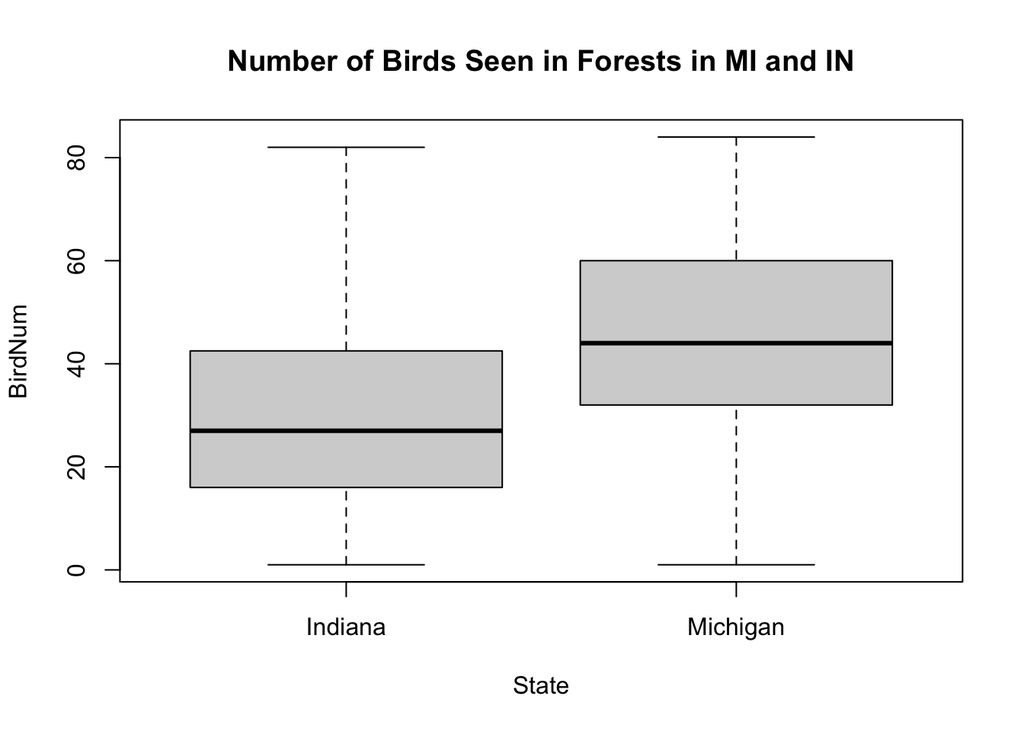

```r
boxplot(BirdNum~State, data=data2, main='Number of Birds Seen in Forests in MI and IN')
```

From the plot there seems a difference between the mean number of birds seen in a forest in Michigan and in Indiana.

## 2.3 c

**Answer**: 2 groups, continuous y and categorical x –> Two sample two tailed t-test

```r
## Check t-test assumptions

# get 2 groups
MI <- filter(data2, State=='Michigan')
IN <- filter(data2, State=='Indiana')

# Equal Variance
var(MI$BirdNum)
```

```
[1] 400.5883
```

```r
var(IN$BirdNum)
```

```
[1] 355.5547
```

```r
var.test(MI$BirdNum, IN$BirdNum)
```

```
    F test to compare two variances

data:  MI$BirdNum and IN$BirdNum
F = 1.1267, num df = 198, denom df = 178, p-value = 0.417
alternative hypothesis: true ratio of variances is not equal to 1
95 percent confidence interval:
 0.8444875 1.4997734
sample estimates:
ratio of variances
          1.126657
```

```r
# Normality
dim(MI)
```

```
[1] 199   2
```

```r
shapiro.test(MI$BirdNum)
```

```
    Shapiro-Wilk normality test

data:  MI$BirdNum
W = 0.98364, p-value = 0.02053
```

```r
dim(IN)
```

```
[1] 179   2
```

```r
shapiro.test(IN$BirdNum)
```

```
    Shapiro-Wilk normality test

data:  IN$BirdNum
W = 0.95828, p-value = 3.706e-05
```

**T-test Assumptions**

- Continuous response data –> Met
- Sample is randomly selected from the population –> Assume so
- Observations are independent –> Assume so
- Equal variance between 2 populations –> From the output of the `var.test()`, the p value is $0.417>\alpha=0.05$. We thus fail to reject $H_0:$ *The variance is equal among the two groups.* Therefore, the assumption of equal variance is met.
- Values are nearly normal or the sample size is large enough –> From the outputs of the `shapiro.test()`, the p values all $<\alpha=0.05$. We thus reject $H_0:$ *The data are normally distributed.* However, although the data are not normally distributed, we have large sample size (199>30, 179>30). Therefore, this assumption is still met.

## 2.4 d

```r
t.test(MI$BirdNum, IN$BirdNum)
```

```
    Welch Two Sample t-test

data:  MI$BirdNum and IN$BirdNum
t = 7.4323, df = 375.19, p-value = 7.288e-13
alternative hypothesis: true difference in means is not equal to 0
95 percent confidence interval:
 10.93119 18.79577
sample estimates:
mean of x mean of y
 45.37186  30.50838
```

**Answer**: From the result of the t-test, the p value is $7.288\times10^{-13}<<\alpha=0.05$. We thus reject $H_0$, and we can say that there is a significant difference between the mean number of birds seen in a forest in Michigan and in Indiana. The mean birds seen in a forest in Michigan (45.4) is higher than than that (30.5) of Indiana.

# 3 Question 3

```r
# average number of cricket chirps heard per hour in different parks across the US
data3 <- read.csv('../data/problemset1/data_q3.csv')
head(data3, 3)
```

```
  Temperature   Chirps
1    21.40962 89.88935
2    15.76820 73.21143
3    21.24025 94.76065
```

## 3.1 a

```r
cor(data3)
```

```
            Temperature    Chirps
Temperature   1.0000000 0.7804302
Chirps        0.7804302 1.0000000
```

**Answer**: The correlation between temperature and number of cricked chirps is 0.78. This is a strong *positive* correlation. It means when temperature increases, chirps increases, and vice versa.

## 3.2 b

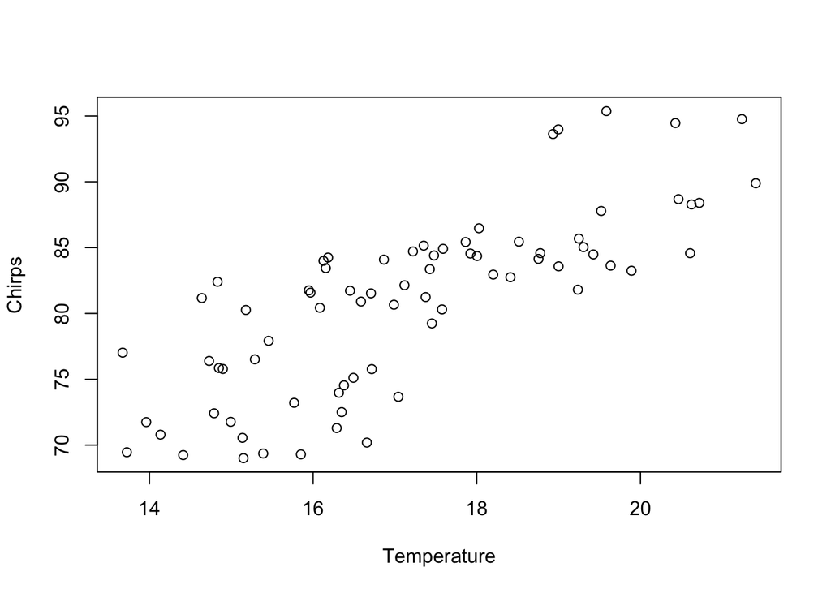

```r
plot(Chirps~Temperature, data=data3)
```

## 3.3 c

**Answer**:

- $H_0:$ There is no significant relationship between `Chirps` and `Temperature`.
- $H_1:$ There is a significant relationship between `Chirps` and `Temperature`.

## 3.4 d

**Answer**: continuous y and continuous x –> Linear regression.

```r
## Check linear regression assumptions
mod <- lm(Chirps~Temperature, data=data3)

# linear relationship --> see the scatter plot above

# Residual Normality
shapiro.test(residuals(mod))
```

```
    Shapiro-Wilk normality test

data:  residuals(mod)
W = 0.98665, p-value = 0.62
```

```r
# Homoscedasticity
ncvTest(mod)
```

```
Non-constant Variance Score Test
Variance formula: ~ fitted.values
Chisquare = 0.717252, Df = 1, p = 0.39705
```

**Linear Regression Assumptions**:

- There is a linear relationship between the variables –> According to the scatter plot, met.
- Statistical independence of the errors –> Assume so
- Normality of the error distribution –> According to the output of the `shapiro.test()`, the p value is $0.62>\alpha=0.05$. We thus fail to reject $H_0:$ *The residuals are normally distributed.* Therefore, the assumption of residual normality is met.
- Homoscedasticity –> According to the output of the `ncvTest()`, the p value is $0.397>\alpha=0.05$. We thus fail to reject $H_0:$ *The variance is constant*. Therefore, the assumption of homoscedasticity is met.

## 3.5 e

```r
summary(mod)
```

```
Call:
lm(formula = Chirps ~ Temperature, data = data3)

Residuals:
    Min      1Q  Median      3Q     Max
-9.2856 -2.8206 -0.1462  2.8785  8.2719

Coefficients:
            Estimate Std. Error t value Pr(>|t|)
(Intercept)  35.1067     4.3184    8.13 8.04e-12 ***
Temperature   2.6636     0.2498   10.66  < 2e-16 ***
---
Signif. codes:  0 '***' 0.001 '**' 0.01 '*' 0.05 '.' 0.1 ' ' 1

Residual standard error: 4.22 on 73 degrees of freedom
Multiple R-squared:  0.6091,    Adjusted R-squared:  0.6037
F-statistic: 113.7 on 1 and 73 DF,  p-value: < 2.2e-16
```

**Answer:**

- The slope is 2.66. This means for every 1 unit increase in `Temperature`, the `Chirps` increases by 2.6636. The p value is $2\times10^{-16}<<\alpha=0.05.$ Therefore we reject $H_0:Slope=0$, there is a significant relationship between chirps and temperature
- The intercept is 35.1067. This means that when `Temperature` is zero, `Chirps` is predicted to be 35.1067. The p value is $8.04\times10^{-12}<<\alpha=0.05$, meaning the `Chirps` is significantly different from zero when `Temperature` is zero.

## 3.6 f

**Answer:** According to the output of the model summary, we have an $R^2$ of 0.609. This means 60.9% of the variation in `Chirps` is explained by `Temperature`, which is a good fit.

# 4 Question 4

```r
# person type and their pet
data4 <- read.csv('../data/problemset1/data_q4.csv')
head(data4, 3)
```

```
     social pet
1 extrovert dog
2 extrovert dog
3 extrovert dog
```

## 4.1 a

**Answer**:

- $H_0:$ A person’s social disposition is independent of their pet.
- $H_A:$ A person’s social disposition is not independent of their pet.

## 4.2 b

**Answer**: categorical y and x –> Chi-square

```r
# get contingency table
table.pet <- table(data4$pet, data4$social)
table.pet
```

```
       extrovert introvert
  bird         5        10
  cat         20        40
  dog         30         5
```

**Chi-square Test Assumptions**

- Data in cells are counts/frequencies –> Met
- Categories are mutually exclusive –> Met
- Samples must be independent –> Assume so
- All cells must be filled, more than 5 obs –> Met

```r
# run the test
chisq.test(table.pet)
```

```
    Pearson's Chi-squared test

data:  table.pet
X-squared = 26.19, df = 2, p-value = 2.055e-06
```

## 4.3 c

**Answer**: According to the Chi-square test result, the p value is $2.055\times10^{-6}$, we therefore reject $H_0$. We can say that a person’s social disposition associated with their pet, with introvert person more likely to have a bird or cat, and extrovert person more likely to have a dog.